# Peer Assessment 1

**Loading and Processing the Data**

1. Load the Data

```r
activity<-read.csv("activity.csv")
```

2. Transform the data as needed
- Updating Date to Date format
- Removing NAs
- Placing in tbl format to use dpylr

```r
activity$date<-as.Date(activity$date)
activity<-na.omit(activity)
library(dplyr)
activity<-tbl_df(activity)
```

**What is mean total number of steps taken per day?**

1. Calculate the total number of steps taken per day

```r
daily_steps <- activity %>%
                group_by(date) %>%
                summarize(total_steps=sum(steps))
```

2. Make a histogram of Steps per Day

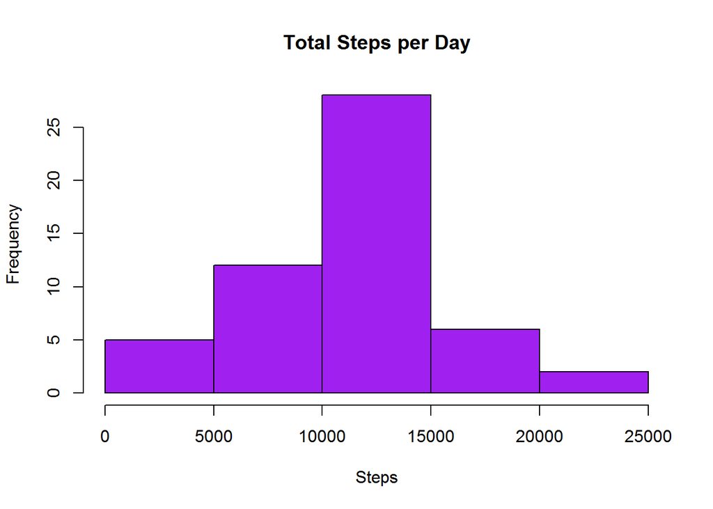

```r
hist(daily_steps$total_steps, main="Total Steps per Day", xlab="Steps",col="purple")
```

```r
step_stats <- daily_steps %>%
                summarize(mean_steps=mean(total_steps),median_steps=median(total_steps))
```

**What is the average daily activity pattern?**

1.Make a time series plot (i.e. type = “l”) of the 5-minute interval (x-axis) and the average number of steps taken, averaged across all days (y-axis) - First Summarize - Then Plot

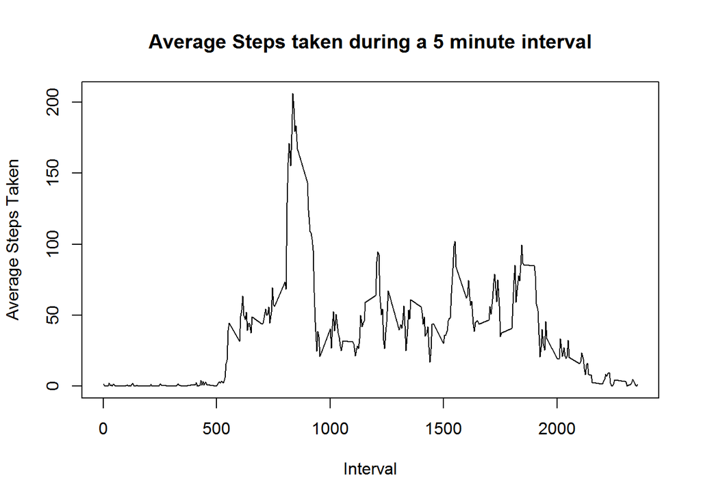

```r
interval<- activity %>%
            group_by(interval) %>%
            summarize(mean_steps=mean(steps))

plot(interval$interval,interval$mean_steps,type="l",xlab="Interval",ylab = "Average Steps Taken",
     main="Average Steps taken during a 5 minute interval")
```

2.Which 5-minute interval, on average across all the days in the dataset, contains the maximum number of steps?

```r
max_int<-interval$interval[which.max(interval$mean_steps)]
```

-The Maximum average steps took place during interval 835

**Imputing missing values**  
1.Calculate and report the total number of missing values in the dataset (i.e. the total number of rows with NAs) - Since I originally removed the missings, I am reading back in the data - Then using summary to see which variables have missing values

```r
activity2<-read.csv("activity.csv")
activity2$date<-as.Date(activity2$date)
summary(activity2)
```

```
##      steps             date               interval
##  Min.   :  0.00   Min.   :2012-10-01   Min.   :   0.0
##  1st Qu.:  0.00   1st Qu.:2012-10-16   1st Qu.: 588.8
##  Median :  0.00   Median :2012-10-31   Median :1177.5
##  Mean   : 37.38   Mean   :2012-10-31   Mean   :1177.5
##  3rd Qu.: 12.00   3rd Qu.:2012-11-15   3rd Qu.:1766.2
##  Max.   :806.00   Max.   :2012-11-30   Max.   :2355.0
##  NA's   :2304
```

- Since Steps is the only variable with missing values, that is the only variable I need to count for missings

```r
missings<-sum(is.na(activity2$steps))
```

- The total number of missing values is 2304

2.Devise a strategy for filling in all of the missing values in the dataset. The strategy does not need to be sophisticated. For example, you could use the mean/median for that day, or the mean for that 5-minute interval, etc.  
- I am going to fill in the median number of average steps per interval step  
- Average number of steps per interval is saved in interval already, just need to find median

3.Create a new dataset that is equal to the original dataset but with the missing data filled in.

```r
int_med<- interval %>%
          summarize(med=median(mean_steps))

for (i in 1:nrow(activity2)) {
    if (is.na(activity2$steps[i])) {
        activity2$steps[i] <- int_med$med
    }
}
summary(activity2)
```

```
##      steps             date               interval
##  Min.   :  0.00   Min.   :2012-10-01   Min.   :   0.0
##  1st Qu.:  0.00   1st Qu.:2012-10-16   1st Qu.: 588.8
##  Median :  0.00   Median :2012-10-31   Median :1177.5
##  Mean   : 36.95   Mean   :2012-10-31   Mean   :1177.5
##  3rd Qu.: 34.11   3rd Qu.:2012-11-15   3rd Qu.:1766.2
##  Max.   :806.00   Max.   :2012-11-30   Max.   :2355.0
```

- There are no longer any missings

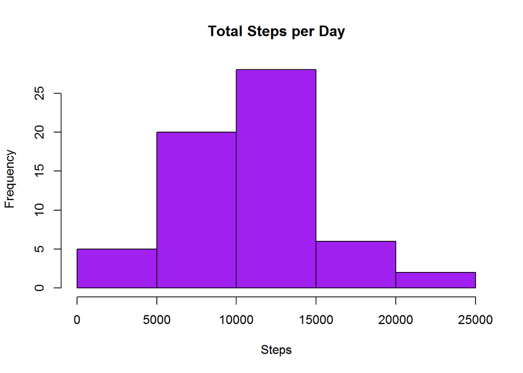

```r
new_sum<- activity2 %>%
          group_by(date)%>%
          summarize(total_steps=sum(steps))
hist(new_sum$total_steps, main="Total Steps per Day", xlab="Steps",col="purple")
```

```r
new_stats<- new_sum %>%
            summarize(mean_steps=mean(total_steps),med_steps=mean(total_steps))
```

**Are there differences in activity patterns between weekdays and weekends?** 1.Create a new factor variable in the dataset with two levels - “weekday” and “weekend” indicating whether a given date is a weekday or weekend day. - Figure out Day of week with weekdays() - Assign daytype orginally to weekday - change Day Type on Sat/Sun

```r
activity2$day<-as.factor(weekdays(activity2$date))
activity2$daytype<-"weekday"
activity2$daytype[activity2$day %in% c("Saturday", "Sunday")] <- "weekend"
activity2$daytype<-as.factor(activity2$daytype)
```

2.Make a panel plot containing a time series plot (i.e. type = “l”) of the 5-minute interval (x-axis) and the average number of steps taken, averaged across all weekday days or weekend days (y-axis).

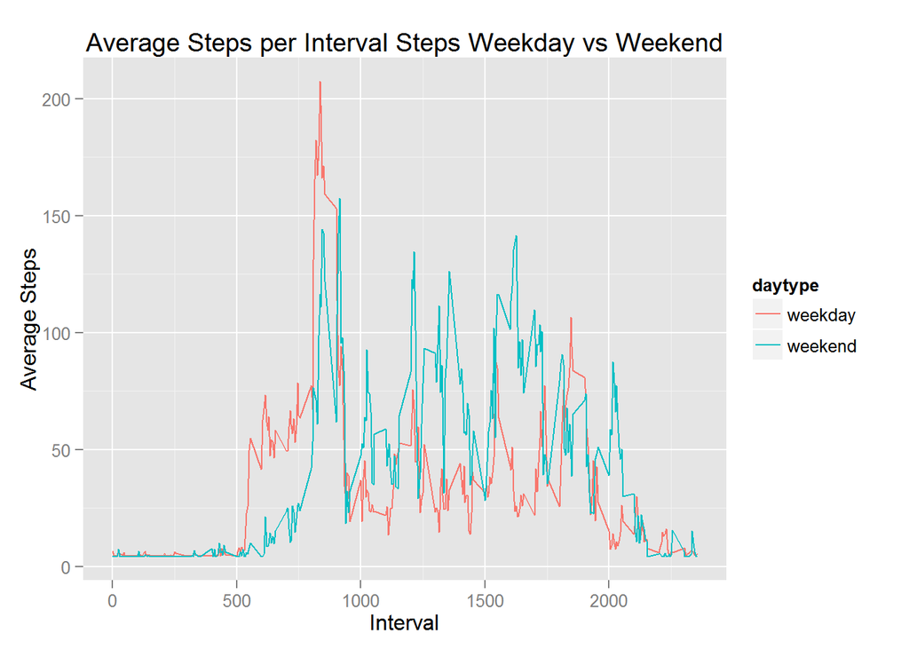

```r
activity3 <- activity2 %>%
            group_by(daytype,interval) %>%
            summarize(mean_int=mean(steps))
library(ggplot2)
ggplot(activity3, aes(x=interval, y=mean_int, group=daytype, color=daytype))+
        geom_line()+
        xlab("Interval")+
        ylab("Average Steps")+
        ggtitle("Average Steps per Interval Steps Weekday vs Weekend")
```